# Ex009_main_analysis

Bin He

## Goal

1. Characterize the **genome-wide** transcriptional response to inorganic phosphate starvation in *C. glabrata*. Compare this to the Pho4-dependent gene induction identified in the *pho80∆* background that causes constitutive activation of Pho4.

   > previously I used RNAseq in *pho80∆* to identify genes induced by Pho4, while measuring Pho4 binding profile under physiological starvation conditions. This dataset will allow me to revisit some of the genes deemed bound but not induced by Pho4 in the previous dataset, to see if they are actually induced under starvation.
2. in addition to identifying the genes that respond to the starvation, but also their kinetics.

   > this is motivated by Barkai group’s Cell Reports study, where they showed that PHO genes in *S. cerevisiae* were induced in two big waves following starvation. I want to see if similar dynamics can be observed in *C. glabrata*

## Experiment set up

In Ex009, I performed time-course transcriptome profiling following inorganic phosphate starvation in two genetic background, namely the wild-type and *pho4∆*. The purpose of doing this in *pho4∆* is to distinguish Pho4-dependent vs Pho4-independent gene induction.

The time-course includes a pre-stress (rich media) condition and a series of post-stress time points. The sampling density on the time axis is denser in the beginning, then gradually becoming sparser, in contrast to the regular interval designed used in Barkai’s study. This is so that I can focus on the early time points while restricting the total number of samples I need to collect and process.

The sample sheet is documented here

Below is a simple chart to show the design:

| Genotype | Time point | Replicates | Comment |
| --- | --- | --- | --- |
| 80∆ | rich media | 2 | for consistency check with my previous data |
| 80∆ 4∆ | rich media | 2 | for consistency check with my previous data |
| wt-1 | pre, 20’, 30’, 45’, 60’, 90’, 120’, 150’, 180’, 240’ | 1 | time course for wt |
| 4∆-1 | pre, 20’, 30’, 45’, 60’, 90’, 120’, 150’, 180’, 240’ | 1 | time course for 4∆ |
| wt-2 | pre, 20’, 30’, 45’, 60’, 120’, 180’, 240’ | 1 | biol. repl. for wt-1 |
| 4∆-2 | pre, 20’, 30’, 45’, 60’, 120’, 180’ | 1 | biol. repl. for 4∆-1 |

## Prepare data

```r
require(tidyverse)     ## for plotting
require(cowplot)       ## for some useful defaults in ggplot2
require(limma)         ## for differential gene expression analysis
require(data.table)    ## for fast importing and manipulating data tables
require(edgeR)         ## for DGEList()
require(RColorBrewer)  ## for plotting
require(NMF)           ## for heatmap plot
require(gplots)        ## for heatmap plot
require(aroma.light)   ## for exploratory analysis
source("../code/R_subfunctions_20171026.R")  ## custom defined functions
```

```r
# raw data count
raw <- fread("../data/gene_count/Ex009_reads_per_transcript_2017-10-18.txt", key = "gene.names")
# sample sheet
sample <- fread("../data/sample_sheet/Ex009_experiment_set_up_20171019.csv")
sample[,Timepoint:=factor(Timepoint, levels = c("pre","20m","30m","45m","60m","90m","120m","150m","180m","240m","del80"))]
sample[,Group:=paste(Genotype,Timepoint, sep=".")]
# rearrange the columns in `raw` according to the samples order in `sample`
ind <- match( c(sample$Sample, "gene.names"), names(raw) )
raw <- raw[,ind,with=FALSE]
# annotation
anno.file <- fread("../data/annotation/C_glabrata_gene_for_mapping_s02-m07-r04.bed")
names(anno.file) <- c("Chr","Start","End","GeneID","Not.Use","Strand","GeneName","Type.of.Gene")
anno <- anno.file[,c("Chr","GeneID","GeneName","Type.of.Gene")]
setkey(anno, "GeneID")
cgToSc <- read_tsv("../data/annotation/C_glabrata_CBS138_S_cerevisiae_orthologs.txt", comment = "#",
                   col_names = c("cgid","cgname","cgid2","scid","scname","scid2"))
cgToSc <- as.data.table(cgToSc)
setkey(cgToSc, "cgid")
```

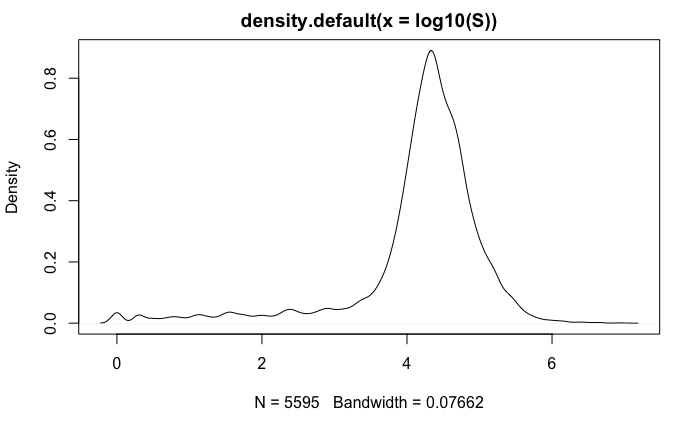

```r
# filter dataset to remove very lowly expressed genes
# 1. examine the distribution of reads for each gene across all samples, to establish a threshold
S <- rowSums(raw[,1:40])
plot(density(log10(S)))
```

```r
sprintf("The number of genes with less than 40 total counts across 40 samples, i.e. 1 read per sample on average is %d, and those with less than 100 total counts, or 2.5 reads per sample, is %d", sum(S<=40), sum(S<=100))
```

```
[1] "The number of genes with less than 40 total counts across 40 samples, i.e. 1 read per sample on average is 335, and those with less than 100 total counts, or 2.5 reads per sample, is 392"
```

```r
print("Let's try 40 reads as a cutoff for dropping genes with low or no expression")
```

```
[1] "Let's try 40 reads as a cutoff for dropping genes with low or no expression"
```

```r
# 2. filter dataset
isexpr <- (S <= 40)
use.genes <- grepl("ncRNA|ORF|pseudogene", anno$Type.of.Gene)
use <- (!isexpr & use.genes)
mat <- as.matrix(raw[use, 1:40])
anno.all <- anno; anno <- anno.all[use]

# 3. write out the filtered table (uncomment if changes are made to the filtering steps above)
#write.table(as.data.frame(raw[use]), file = paste("../data/gene_count/Ex009_reads_per_transcript_filtered_", Sys.Date(), ".txt", sep = ""), quote = FALSE, row.names = FALSE)
```

## Exploratary analysis

*Goal*

- visualize the between sample variation in the raw read count distribution, so as to assess the need of normalization and to choose the appropriate method
- examine variability between technical and biological replicates, and separation between treatment, on an MDS plot

*Reference*

[RUVSeq manual on Bioconductor](http://bioconductor.org/packages/release/bioc/vignettes/RUVSeq/inst/doc/RUVSeq.pdf)

### 1. Explore different normalization methods

[output not shown]

```r
# Print sample information
print(sample[,.(Sample, Strain, Genotype, Timepoint, Replicate)])
```

| Sample | Strain | Genotype | Timepoint | Replicate |
| --- | --- | --- | --- | --- |
| S1 | HY6 | del4 | del80 | 1 |
| S2 | HY7 | del4 | del80 | 2 |
| S3 | HY1 | wt | pre | 1 |
| S4 | HY2 | wt | pre | 2 |
| S5 | HY5 | del4 | pre | 1 |
| S6 | HY5 | del4 | pre | 2 |
| S7 | HY1 | wt | 20m | 1 |
| S8 | HY2 | wt | 20m | 2 |
| S9 | HY5 | del4 | 20m | 1 |
| S10 | HY5 | del4 | 20m | 2 |

[output cut: 30 more lines]

```r
# visualize the between sample variation pre-normalization
print("Non-normalized")
```

```
[1] "Non-normalized"
```

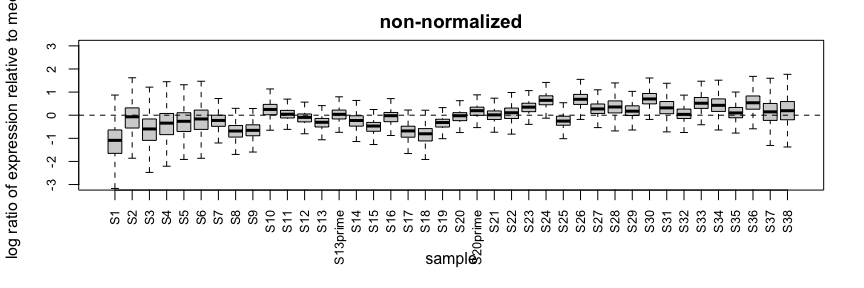

```r
myPlotRLE(mat, outline=FALSE, ylim= c(-3, 3), cex.axis = 0.8, las = 3)
title(main = "non-normalized", xlab = "sample", ylab = "log ratio of expression relative to median")
```

```r
# try upper quantile normalization
print("Upper-quantile normalized")
```

```
[1] "Upper-quantile normalized"
```

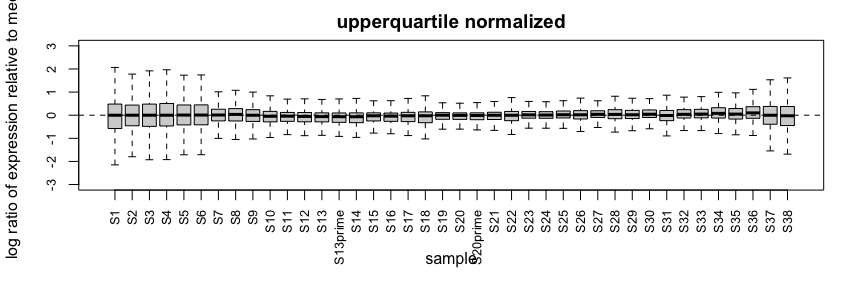

```r
set1 <- myBetweenLaneNormalization(mat, which="upper")
myPlotRLE(set1, outline=FALSE, ylim=c(-3, 3), cex.axis = 0.8, las = 3)
title(main = "upperquartile normalized", xlab = "sample", ylab = "log ratio of expression relative to median")
```

```r
# try full quantile normalization
print("Full-quantile normalized")
```

```
[1] "Full-quantile normalized"
```

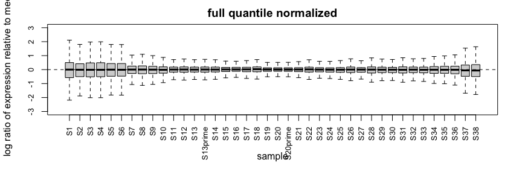

```r
set2 <- myBetweenLaneNormalization(mat, which="full")
myPlotRLE(set2, outline=FALSE, ylim=c(-3, 3), cex.axis = 0.8, las = 3)
title(main = "full quantile normalized", xlab = "sample", ylab = "log ratio of expression relative to median")
```

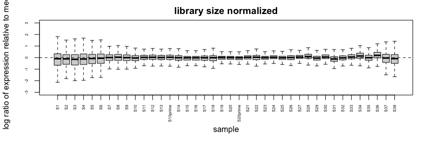

```r
# try TMM normalization
# 1. construct count matrix
dge <- DGEList( counts = mat, genes = anno )
# 2. perform TMM normalization
dge <- calcNormFactors(dge)
# 3. calculate log transformed, normalized counts
cpm.o <- cpm( dge, normalized.lib.sizes = FALSE, log = FALSE) # unnormalized
cpm.n <- cpm( dge, normalized.lib.sizes = TRUE, log = FALSE) # normalized
myPlotRLE(cpm.o, outline=FALSE, ylim=c(-3, 3), cex.axis = 0.5, las = 3)
title(main = "library size normalized", xlab = "sample", ylab = "log ratio of expression relative to median")
```

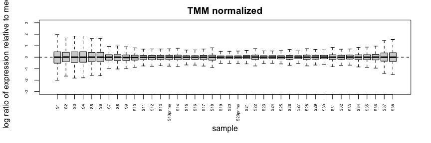

```r
myPlotRLE(cpm.n, outline=FALSE, ylim=c(-3, 3), cex.axis = 0.5, las = 3)
title(main = "TMM normalized", xlab = "sample", ylab = "log ratio of expression relative to median")
```

Sample S1-6 and S37,38 have larger variance than the rest of the samples. One thing in common about these 8 samples is that they were grown in rich media, although some of the strains are supposed to have PHO activated just as the starved samples are. I suspect the higher variance is a result of the 40 samples being dominated by starved conditions (both wt and *pho4∆*), which may share a general transcriptional profile compared to the high Pi samples. Since RLE compares each sample to the median of all samples, the dominance by starved samples would cause high deviation for the minority samples collected in high Pi. To test this hypothesis, I predict that an RLE plot with 6 high Pi and 6 low Pi samples would look much more similar to each other. And that’s what I saw below.

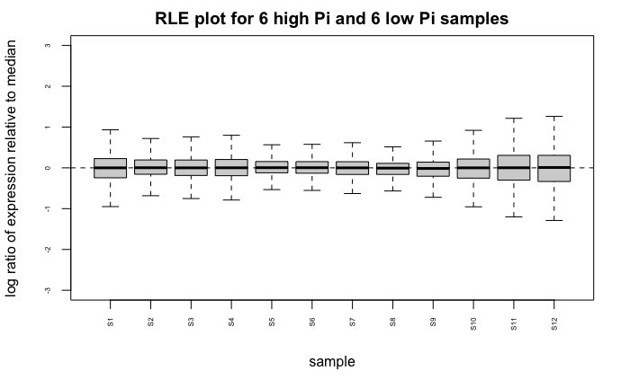

```r
myPlotRLE( cpm.n[,c(1:12)], outline=FALSE, ylim=c(-3, 3), cex.axis = 0.5, las = 3)
title(main = "RLE plot for 6 high Pi and 6 low Pi samples", xlab = "sample", ylab = "log ratio of expression relative to median")
```

*Conclusion*

- All three methods tried, i.e. TMM, upperquartile and full quantile normalization similarly removed the position differences in the box plots.
- The distribution of log radio of expression is greater for S1-S6, S37 and S38. The reason is because the 40 samples are dominated by starved cells, which probably share a lot of transcriptional changes (independent of Pho4). The way RLE is calculated means that the median value, which is the denominator in the ratio, is largely determined by the majority sample type. Consequently, the minority sample type will show large variances. This does suggest that the assumption of the RLE plot, namely the majority of genes are not differentially expressed, is not satisfied, and that Pi starvation induces a large transcriptional response, most of which are not Pho4-dependent.
- I also looked at other properties of the samples and sequencing stat, such as the amount of RNA extracted, number of PCR cycles used for making the library, total number of reads obtained and number of reads mapped. None suggested quality differences between S1-6, S37, S38 with the rest samples.

```r
# 1. construct count matrix
dge <- DGEList( counts = mat, genes = anno )
# 2. perform TMM normalization
dge <- calcNormFactors(dge)
# 3. use TMM to normalize data
lcpm <- cpm( dge, normalized.lib.sizes = TRUE, log = TRUE, prior.count = 0.5)
rownames(lcpm) <- anno$GeneID
# 4. save the data for the shiny app
save(lcpm, anno, cgToSc, sample, file = "./shiny-app/R_obj.RData")
```

### 2. MDS plot

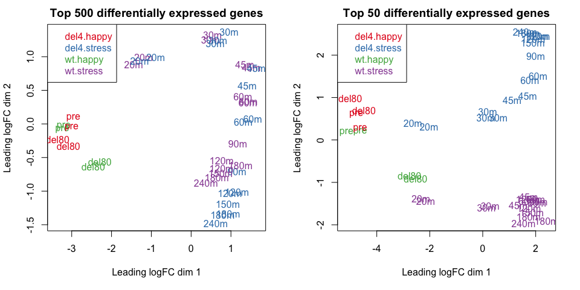

**Conclusion**

- The first dimension (leading logFC dim 1), which explains the most variation, mainly separates the non-stressed samples (including del80.del4) and the stressed ones. The del80.PHO4 sample is only slightly removed from the unstressed ones suggesting that Pho4-dependent gene induction probably represents a rather small fraction of the genes whose expression change upon stress.
- On the left graph, which used top 500 differentially expressed genes (see manual of plotMDS for details), we see that the stressed samples nicely align themselves in the order that largely match their time under stress (from top to bottom: 30’m 45’, 60’, 90’, 120-240’). The del4 and PHO4 samples with matching time points group together, again suggesting that the majority of transcriptional responses after Pi starvation are Pho4-independent.
- I reasoned that the more strongly a gene is induced, the more likely it is under direct Pho4 regulation. Based on this assumption, I used the top 50 genes to construct the MDS plot (right). Here it indeed changed some of the features. Specifically,
  1. the first dimention still mainly separates the non-stressed from the stressed samples. This time however, it also displays a progression that matches the time under stress.
  2. More interestingly, the second dimension now separates the del4 vs PHO4-wt samples. Moreover, it unexpected spreads the different time point samples, but only for del4 ones. The meaning of this is yet unclear.

### 3. Single gene analysis

*Goal*

- Visualize a few known Pho4 target genes and compare them to my expectation.

*Approach*

I wrote a sub-function in a separate file and source it here.

```r
# Gene lists based on He et al 2017 eLife
# 1. conserved (all PHO related) targets with S. cerevisiae
set1 <- c("CAGL0B02475g", "CAGL0A01243g", "CAGL0L05456g", "CAGL0C02321g", "CAGL0G06952g", "CAGL0L06622g", "CAGL0M12705g", "CAGL0F02145g", "CAGL0J07040g", "CAGL0K12034g")
# 2. Cg. specific PHO related
set1.1 <- c("CAGL0K07546g", "CAGL0M11660g", "CAGL0B02453g", "CAGL0F02387g", "CAGL0K07524g", "CAGL0M12430g")
# 3. Sc. specific PHO related
set1.2 <- c("CAGL0M09823g","CAGL0K04939g","CAGL0H07359g","CAGL0L04422g","CAGL0F02035g","CAGL0H01815g")
# 4. other stress related
set2 <- c("CAGL0E05588g", "CAGL0M13189g", "CAGL0E05566g", "CAGL0E05984g", "CAGL0M11660g", "CAGL0G01540g", "CAGL0K10604g", "CAGL0J04202g", "CAGL0L06644g", "CAGL0K10164g", "CAGL0M06325g", "CAGL0C04741g", "CAGL0E04356g")
# 5. cell wall and adhesion
set3 <- c("CAGL0J04202g", "CAGL0M07634g", "CAGL0M12430g", "CAGL0E05940g", "CAGL0K10164g", "CAGL0L06424g", "CAGL0L07502g", "CAGL0M08514g", "CAGL0J06050g", "CAGL0F00649g", "CAGL0M06325g", "CAGL0B02926g", "CAGL0B02970g", "CAGL0I00726g")

print( cgToSc[set1, .(cgid, cgname, scid,scname)])
```

| cgid | cgname | scid | scname |
| --- | --- | --- | --- |
| CAGL0B02475g | PHO84 | YML123C | PHO84 |
| CAGL0A01243g | NA | NA | NA |
| CAGL0L05456g | PHO86 | YJL117W | PHO86 |
| CAGL0C02321g | PHM8 | YER037W | PHM8 |
| CAGL0G06952g | PHM3 | YJL012C | VTC4 |
| CAGL0L06622g | PHO81 | YGR233C | PHO81 |
| CAGL0M12705g | NA | NA | NA |
| CAGL0F02145g | PHM1 | YFL004W | VTC2 |
| CAGL0J07040g | NA | YPL110C | GDE1 |
| CAGL0K12034g | ENA1 | YDR040C | ENA1 |

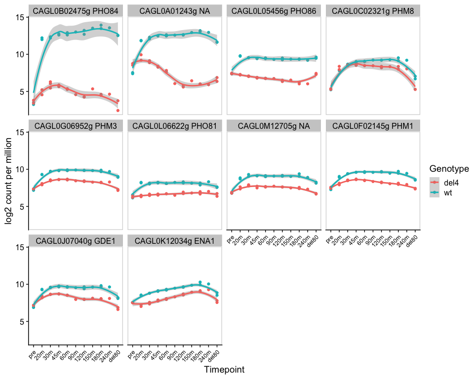

```r
myGenePlot(genes = set1)
```

```r
print( cgToSc[set1.1, .(cgid, cgname, scid,scname)])
```

| cgid | cgname | scid | scname |
| --- | --- | --- | --- |
| CAGL0K07546g | NA | NA | NA |
| CAGL0M11660g | NA | NA | NA |
| CAGL0B02453g | NA | YML121W | GTR1 |
| CAGL0F02387g | PHO87 | YJL198W | PHO90 |
| CAGL0K07524g | PMU1 | YKL128C | PMU1 |
| CAGL0M12430g | RHR2 | YIL053W | GPP1 |

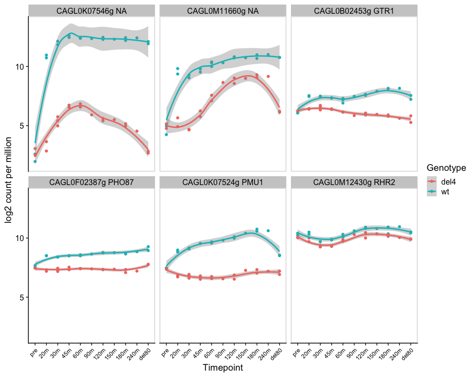

```r
myGenePlot(genes = set1.1)
```

```r
print( cgToSc[set2, .(cgid, cgname, scid,scname)])
```

| cgid | cgname | scid | scname |
| --- | --- | --- | --- |
| CAGL0E05588g | NA | YOR346W | REV1 |
| CAGL0M13189g | MSN4 | YKL062W | MSN4 |
| CAGL0E05566g | NA | YOR344C | TYE7 |
| CAGL0E05984g | NA | YPL223C | GRE1 |
| CAGL0M11660g | NA | NA | NA |
| CAGL0G01540g | NCE103 | YNL036W | NCE103 |
| CAGL0K10604g | NA | YFR014C | CMK1 |
| CAGL0J04202g | HSP12 | YFL014W | HSP12 |
| CAGL0L06644g | NA | NA | NA |
| CAGL0K10164g | NA | YDR077W | SED1 |

[output cut: 3 more lines]

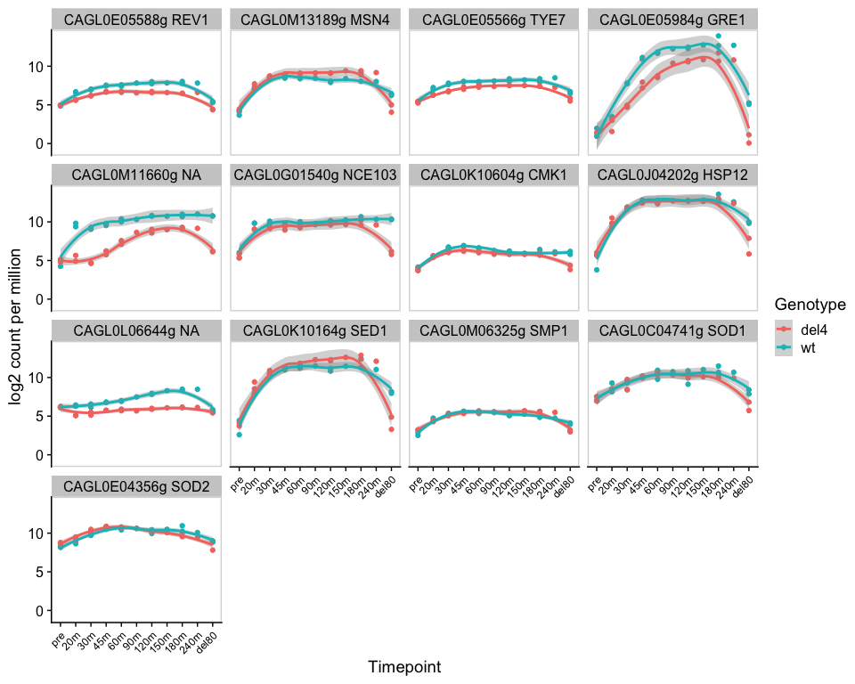

```r
myGenePlot(genes = set2)
```

```r
print( cgToSc[set3, .(cgid, cgname, scid,scname)])
```

| cgid | cgname | scid | scname |
| --- | --- | --- | --- |
| CAGL0J04202g | HSP12 | YFL014W | HSP12 |
| CAGL0M07634g | NA | YMR016C | SOK2 |
| CAGL0M12430g | RHR2 | YIL053W | GPP1 |
| CAGL0E05940g | NA | YPL221W | FLC1 |
| CAGL0K10164g | NA | YDR077W | SED1 |
| CAGL0L06424g | NA | NA | NA |
| CAGL0L07502g | NA | YBR067C | TIP1 |
| CAGL0M08514g | PIR5 | YKL163W | PIR3 |
| CAGL0J06050g | NA | YNL160W | YGP1 |
| CAGL0F00649g | NA | NA | NA |

[output cut: 4 more lines]

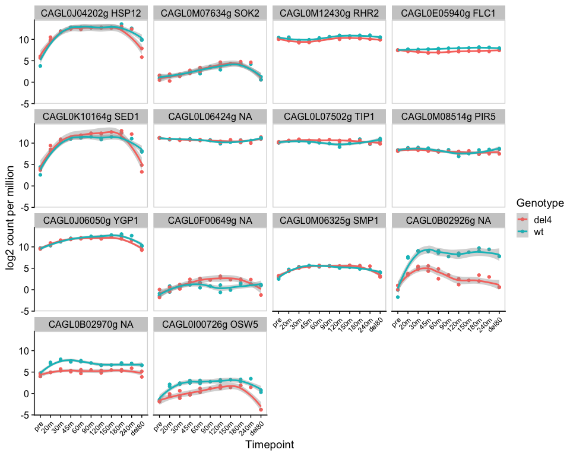

```r
myGenePlot(genes = set3)
```

*Conclusion*

## Compare with 2013 data ( *pho80∆* )

*Goal*

Check if the gene list under pho80∆ background in this experiment is consistent with previous results.

*Steps*

1. Load raw counts from previous result.
2. Extract the subset of data to be used.
3. Filter the data using the same gene list as in this analysis.
4. Normalize the data using the same method, but separately for the 2013 data.
5. Apply LIMMA-voom to identify top gene lists

*Analyses*

```r
# I. Load data
raw13 <- fread("../data/gene_count/2013_Cgla_reads_per_transcript_2016-02-21.txt") # checked to make sure that the gene names align with raw
sample13 <- fread("../data/sample_sheet/2013_CglaRNAseq_sample_info.csv")
# what I need is sample N1, N2, O1, O2, which correspond to S37, S38, S1, S2
# also use the same gene filtering I used for the current analysis
mat13 <- as.matrix( raw13[use, .(N1,N2,O1,O2)] )

# II. now combine the two experiments into one
mat.d80 <- cbind( mat[,c("S37","S38","S1","S2")], mat13 )
# and create the appropriate sample sheet
sample.d80 <- read.table(strip.white = TRUE, text = "Sample, Pho4, Exp
                         S37, Cgla4, 2017
                         S38, Cgla4, 2017
                         S1, del4, 2017
                         S2, del4, 2017
                         N1, Cgla4, 2013
                         N2, Cgla4, 2013
                         O1, del4, 2013
                         O2, del4, 2013", sep = ",", head = TRUE )

# III. apply TMM normalization
# 0. visualize the between sample unwanted variation using Relative Log Expression (RLE)
oldpar <- par( mfcol = c(1,2) )
myPlotRLE( mat.d80, outline = FALSE, ylim = c(-2.3,2.3), las = 2, main = "RLE plot before normalization" )
# 1. construct count matrix
dge.d80 <- DGEList( counts = mat.d80, genes = anno )
# 2. perform TMM normalization
dge.d80 <- calcNormFactors(dge.d80)
# 3. use TMM to normalize data
cpm.d80 <- cpm( dge.d80, normalized.lib.sizes = TRUE, log = FALSE, prior.count = 0.5)
# 4. examine the RLE plot after normalization
myPlotRLE( cpm.d80, outline = FALSE, ylim = c(-2.3,2.3), las = 2, main = "RLE plot after normalization" )
# 5. finish the normalization with log transformation
lcpm.d80 <- cpm( dge.d80, normalized.lib.sizes = TRUE, log = TRUE, prior.count = 0.5)
rownames(lcpm.d80) <- anno$GeneID

# IV. bird-eye view of similarity between samples
plotMDS( lcpm.d80, top = 500, main = "MDS plot with top 500 DE genes")
plotMDS( lcpm.d80, top = 50,  main = "MDS plot with top 50  DE genes")
par( oldpar )
```

[output not shown]

```r
layout(matrix(c(1,2,0,3), ncol = 2))
# the goal here is to perform differential gene expression analysis, separately for 2013 and 2017 data
# create design matrix
grp <- with(sample.d80, paste(Pho4,Exp,sep="."))
dsgn.d80 <- model.matrix(~0+grp)
colnames(dsgn.d80) <- gsub("grp","",colnames(dsgn.d80))
# voom transformation to account for variance-mean dependence
v.dge.d80 <- voom(dge.d80, design = dsgn.d80, plot = TRUE)
# v.dge.d80 <- voomWithQualityWeights(dge.d80, design = dsgn.d80, plot = TRUE) # incorporate sample weights

# LIMMA fit
fit.d80 <- lmFit(v.dge.d80, design = dsgn.d80) # this automatically extracts the weights in the v.dge.d80 and uses it to perform a weighted linear regression

# make contrasts
contr.d80 <- makeContrasts(
  Pho4.13 = Cgla4.2013 - del4.2013,
  Pho4.17 = Cgla4.2017 - del4.2017,
  Cgla4.13vs17 = Cgla4.2013 - Cgla4.2017,
  del4.13vs17 = del4.2013 - del4.2017,
  levels  = dsgn.d80
)
fit.d80 <- contrasts.fit(fit.d80, contrasts = contr.d80)
fit.d80 <- eBayes( fit.d80 )
sig.d80 <- decideTests( fit.d80, method = "global", lfc = 1 ) # only include genes more than 2 fold induced
choose <- rowSums(sig.d80[,1:2]) >= 1 # select genes that are deemed significant in at least one exp.
test <- coef(fit.d80)[choose,]
lm <- lm(test[,"Pho4.13"]~test[,"Pho4.17"])

# plot to compare the two results
plot(coef(fit.d80)[choose,1:2], cex = 0.75, pch = 19, col = rgb(0,0,0,0.6), xlab = "2013", ylab = "2017", main = "log2 fold-change", sub = paste("Pearson's r = ", round(cor(test[,1],test[,2]),2) ,sep="") )

# plot the overlap between the two list
vennDiagram( sig.d80[,1:2], include = "up", circle.col = c("turquoise","salmon") )

# plot heatmap
sprintf("A totle of %d genes were selected because they were significantly induced by more than 2 fold in at least one of the two experiments.", sum(choose))
mycol <- colorpanel(1000,"blue","black","yellow")
heatmap.2(v.dge.d80$E[choose,], scale="row",Rowv = TRUE,
   labRow=NA, labCol=colnames(v.dge.d80),
   col=mycol, trace="none", density.info="none",
   margin=c(8,6), lhei=c(2,10), dendrogram="none")

# Mean-difference plots to visualize the differences
layout(matrix(c(1,3,2,4), ncol = 2))
name.contr.d80 <- c("Pho4-dependent gene induction, 2013",
                    "Pho4-dependent gene induction, 2017",
                    "DE between 2013 and 2017 with Pho4",
                    "DE between 2013 and 2017 w/o Pho4")
for( i in 1:4 ){
  plotMD(fit.d80, coef = i, status = sig.d80[,i], main = name.contr.d80[i], ylim = c(-10,10))
}
```

[output not shown]

*Conclusion*

```r
print(topTable( fit.d80, coef = c(1,2), n = 50 )) # by specifying coef=c(1,2), I'm including the estimates of Pho4 effect in both 2017 and 2013 data. topTable will perform a F-test by calling topTalbeF to identify genes that are differentially expressed in at least one of the two comparisons, ranked by the overall evidence of DE.

# same procedure as the analysis above, but pooling 2013 and 2017 datasets
grp2 <- sample.d80$Pho4
dsgn.d80.2 <- model.matrix(~0+grp2)
colnames(dsgn.d80.2) <- gsub("grp2","",colnames(dsgn.d80.2))
# voom transformation to account for variance-mean dependence
v.dge.d80.2 <- voom(dge.d80, design = dsgn.d80.2, plot = FALSE)

# LIMMA fit
fit.d80.2 <- lmFit(v.dge.d80.2, design = dsgn.d80.2) # this automatically extracts the weights in the v.dge.d80 and uses it to perform a weighted linear regression

# make contrasts
contr.d80.2 <- makeContrasts(
  Pho4 = Cgla4 - del4,
  levels  = dsgn.d80.2
)
fit.d80.2 <- contrasts.fit(fit.d80.2, contrasts = contr.d80.2)
fit.d80.2 <- eBayes( fit.d80.2 )
sig.d80.2 <- decideTests( fit.d80.2, method = "global", lfc = 1 ) # only include genes more than 2 fold induced

topTable(fit.d80.2, n = 50)
```

[output not shown]

## Analyze time-course data

### First timepoint

*Questions*

1. How many genes are turned on at 20’? (set1)
2. How many of them are *exclusively* dependent on Pho4, meaning that the gene induction is abolished in *pho4∆*? (set 2)
3. How much does set 2 overlap with the set identified in *pho80∆*?

*Analysis*

```r
# 0. Prepare dataset

#  `dge` contains the data, including the count matrix, the sample normalization factors and gene names
#  `sample` contains the experimental design, including the genotype, pre or post stress (time points if latter)
#  I've already made one variable that combines both genotype and stress conditions
#  note that I included the d80 data in this analysis

dsgn <- model.matrix(~0+sample$Group)
colnames(dsgn) <- gsub("sample$Group","",colnames(dsgn),fixed=TRUE)
# voom transformation to account for variance-mean dependence
v.dge <- voom(dge, design = dsgn, plot = FALSE)

# 1. LIMMA fit the whole dataset
fit <- lmFit(v.dge, design = dsgn) # this automatically extracts the weights in the v.dge and uses it to perform a weighted linear regression

# 2. make contrasts
contr.first <- makeContrasts(
  d80 = wt.del80 - del4.del80,
  wt.t20 = wt.20m - wt.pre,
  del4.t20 = del4.20m - del4.pre,
  diff.t20 = (wt.20m-wt.pre) - (del4.20m-del4.pre),
  levels  = dsgn
)

fit.first <- contrasts.fit(fit, contrasts = contr.first)
fit.first <- eBayes( fit.first )
sig <- decideTests( fit.first, method = "separate", lfc = 1 ) # only include genes more than 2 fold induced

# how many genes are differentially expressed 20 min after starvation?
topTable( fit.first, coef = "diff.t20", n = 50 )
```

[output not shown]